# Basics of estimated marginal means

emmeans package, Version 2.0.0

## Contents

1. Foundations
   1. Emphasis on experimental data
   2. Emphasis on models
   3. Illustration: `pigs` experiment
   4. Estimated marginal means
   5. The reference grid, and definition of EMMs
   6. More on the reference grid
2. Other topics
   1. Passing arguments
   2. Transformations
   3. Derived covariates
   4. Non-predictor variables
   5. Graphical displays
   6. Formatting results
   7. Using weights
   8. Multivariate responses
3. Objects, structures, and methods
4. P values, “significance”, and recommendations
5. Summary
6. Further reading

Index of all vignette topics

## Foundations

### Emphasis on experimental data

To start off with, we should emphasize that the underpinnings of estimated marginal means – and much of what the **emmeans** package offers – relate more to *experimental* data than to *observational* data. In observational data, we sample from some population, and the goal of statistical analysis is to characterize that population in some way. In contrast, with experimental data, the experimenter controls the environment under which test runs are conducted, and in which responses are observed and recorded. Thus with experimentation, the population is an abstract entity consisting of potential outcomes of test runs made under conditions we enforce, rather than a physical entity that we observe without changing it.

We say this because the default behavior of the `emmeans()` function is to average groups together with equal weights; this is common in analysis of experiments, but not common in analysis of observational data; and I think that misunderstandings about this underlie some criticisms such as [are found here](https://stats.stackexchange.com/questions/332167/what-are-ls-means-useful-for) and [here](https://stats.stackexchange.com/questions/510862/is-least-squares-means-lsmeans-statistical-nonsense/510923#510923).

Consider, for example, a classic Latin square experimental design. RA Fisher and others expounded on such designs. Suppose we want to compare four treatments, say fertilizers, in an agricultural experiment. A Latin square plan would involve dividing a parcel of land into four rows and four columns, defining 16 plots. Then we apply one of the fertilizers to each plot in such a way that each fertilizer appears once in each row and once in each column (and thus, each row and each column contains all four fertilizers). This scheme, to some extent, controls for possible spatial effects within the land parcel. To compare the fertilizer, we average together the response values (say, yield of a crop) observed on the four plots where each fertilizer was used. It seems right to average these together with equal weight, because each experimental condition seems equally valid and there is no reason to give one more weight than another. In this illustration, the fertilizer means are not marginal means of some physical population; they are simply the means obtained under the four test conditions defined by the experiment.

### Emphasis on models

The **emmeans** package requires you to fit a model to your data. All the results obtained in **emmeans** rely on this model. So, really, the analysis obtained is really an analysis of the model, not the data. This analysis does depend on the data, but only insofar as the fitted model depends on the data. We use predictions from this model to compute estimated marginal means (EMMs), which will be defined more explicitly below. For now, there are two things to know:

1. If you change the model, that changes the EMMs
2. If the model fits poorly, the EMMs represent the data poorly (the garbage in, garbage out principle)

So to use this package to analyze your data, the most important first step is to fit a good model.

Back to Contents

### Illustration: `pigs` experiment

Consider the `pigs` dataset provided with the package (`help("pigs")` provides details). These data come from an experiment where pigs are given different percentages of protein (`percent`) from different sources (`source`) in their diet, and later we measured the concentration (`conc`) of leucine. The `percent` values are quantitative, but we chose those particular values deliberately, and (at least initially) we want separate estimates at each `percent` level; that is, we want to view `percent` as a factor, not a quantitative predictor.

As discussed, our first task is to come up with a good model. Doing so requires a lot of skill, and we don’t want to labor too much over the details; you really need other references to deal with this aspect adequately. But we will briefly discuss five models and settle on one of them:

```r
mod1 <- lm(conc ~ source * factor(percent), data = pigs)
mod2 <- update(mod1, . ~ source + factor(percent))   # no interaction
```

These models have $R^2$ values of 0.808 and 0.700, and adjusted $R^2$ values of 0.684 and 0.634. `mod1` is preferable to `mod2`, suggesting we need the interaction term. However, a residual-vs-predicted plot of `mod2` has a classic “horn” shape (curving and fanning out), indicating a situation where a response transformation might help better than including the interaction.

It turns out that an inverse transformation, (`1/conc`) really serves us well. (Perhaps this isn’t too surprising, as concentrations are typically determined by titration, in which the actual measurements are volumes; and these are reciprocally related to concentrations, i.e., amounts *per* unit volume.)

So here are three more models:

```r
mod3 <- update(mod1, inverse(conc) ~ .)
mod4 <- update(mod2, inverse(conc) ~ .)     # no interaction
mod5 <- update(mod4, . ~ source + percent)  # linear term for percent
```

(Note: We could have used `1/conc` as the response variable, but **emmeans** provides an equivalent `inverse()` function that will prove more advantageous later.) The residual plots for these models look a lot more like a random scatter of points (and that is good). The $R^2$ values for these models are 0.818, 0.787, and 0.749, respectively; and the adjusted $R^2$s are 0.700, 0.740, and 0.719. `mod4` has the best adjusted $R^2$ and will be our choice.

Back to Contents

### Estimated marginal means

Now that we have a good model, let’s use the `emmeans()` function to obtain estimated marginal means (EMMs). We’ll explain them later.

```r
(EMM.source <- emmeans(mod4, "source"))
```

```
##  source emmean       SE df lower.CL upper.CL
##  fish   0.0337 0.000926 23   0.0318   0.0356
##  soy    0.0257 0.000945 23   0.0237   0.0276
##  skim   0.0229 0.000994 23   0.0208   0.0249
##
## Results are averaged over the levels of: percent
## Results are given on the inverse (not the response) scale.
## Confidence level used: 0.95
```

```r
(EMM.percent <- emmeans(mod4, "percent"))
```

```
##  percent emmean       SE df lower.CL upper.CL
##        9 0.0322 0.001030 23   0.0301   0.0344
##       12 0.0270 0.000969 23   0.0250   0.0290
##       15 0.0263 0.001100 23   0.0240   0.0286
##       18 0.0241 0.001340 23   0.0213   0.0268
##
## Results are averaged over the levels of: source
## Results are given on the inverse (not the response) scale.
## Confidence level used: 0.95
```

Let’s compare these with the ordinary marginal means (OMMs) on `inverse(conc)`:

```r
with(pigs, tapply(inverse(conc), source, mean))
```

```
##       fish        soy       skim
## 0.03331687 0.02632333 0.02372024
```

```r
with(pigs, tapply(inverse(conc), percent, mean))
```

```
##          9         12         15         18
## 0.03146170 0.02700341 0.02602757 0.02659336
```

Both sets of OMMs are vaguely similar to the corresponding EMMs. However, please note that the EMMs for `percent` form a decreasing sequence, while the the OMMs decrease but then increase at the end.

### The reference grid, and definition of EMMs

Estimated marginal means are defined as marginal means of model predictions over the grid comprising all factor combinations – called the *reference grid*. For the example at hand, the reference grid is

```r
(RG <- expand.grid(source = levels(pigs$source), percent = unique(pigs$percent)))
```

```
##    source percent
## 1    fish       9
## 2     soy       9
## 3    skim       9
## 4    fish      12
## 5     soy      12
## 6    skim      12
## 7    fish      15
## 8     soy      15
## 9    skim      15
## 10   fish      18
## 11    soy      18
## 12   skim      18
```

To get the EMMs, we first need to obtain predictions on this grid:

```r
(preds <- matrix(predict(mod4, newdata = RG), nrow = 3))
```

```
##            [,1]       [,2]       [,3]       [,4]
## [1,] 0.03853514 0.03329091 0.03256404 0.03036586
## [2,] 0.03050486 0.02526063 0.02453376 0.02233558
## [3,] 0.02770292 0.02245869 0.02173182 0.01953364
```

then obtain the marginal means of these predictions:

```r
apply(preds, 1, mean)   # row means -- for source
```

```
## [1] 0.03368899 0.02565870 0.02285677
```

```r
apply(preds, 2, mean)   # column means -- for percent
```

```
## [1] 0.03224764 0.02700341 0.02627654 0.02407836
```

These marginal averages match the EMMs obtained earlier via `emmeans()`.

```r
with(pigs, table(source, percent))
```

```
##       percent
## source 9 12 15 18
##   fish 2  3  2  3
##   soy  3  3  3  1
##   skim 3  3  2  1
```

This shows that the OMMs of the last column give most of the weight (3/5) to the first source, which tends to have higher `inverse(conc)`, making the OMM for 18 percent higher than that for 15 percent, even though the reverse is true with every level of `source`. This kind of disconnect is an example of *Simpson’s paradox,* in which a confounding factor can distort your findings. The EMMs are not subject to this paradox, but the OMMs are, when the sample sizes are correlated with the expected values.

In summary, we obtain a references grid of all factor combinations, obtain model predictions on that grid, and then the expected marginal means are estimated as equally-weighted marginal averages of those predictions. Those EMMs are not subject to confounding by other factors, such as might happen with ordinary marginal means of the data. Moreover, unlike OMMs, EMMs are based on a model that is fitted to the data.

Back to Contents

### More on the reference grid

In the previous section, we discussed the reference grid as being the set of all factor combinations. It is slightly more complicated than that when we have numerical predictors (AKA covariates) in the model. By default, we use the average of each covariate – thus not enlarging the number of combinations comprising the grid. Using the covariate average(s) yields what are often called *adjusted means*. There is one exception, though: if a covariate has only two different values, we treat it as a factor having those two levels. For example, a model could include an indicator variable `male` that is `1` if the subject is male, and `0` otherwise. Then `male` would be viewed as a factor with levels `0` and `1`. Note, again, that the reference grid is formulated from the model we are using.

We can see a snapshot of the reference grid via the `ref_grid` function; for example

```r
(RG4 <- ref_grid(mod4))
```

```
## 'emmGrid' object with variables:
##     source = fish, soy, skim
##     percent =  9, 12, 15, 18
## Transformation: "inverse"
```

```r
ref_grid(mod5)
```

```
## 'emmGrid' object with variables:
##     source = fish, soy, skim
##     percent = 12.931
## Transformation: "inverse"
```

The reference grid for `mod5` is different from that for `mod4` because in those models, `percent` is a factor in `mod4` and a covariate in `mod5`.

It is possible to modify the reference grid. In the context of the present example, it might be interesting to compare EMMs based on `mod4` and `mod5`, and we can put them on an equal footing by using the same `percent` values as reference levels:

```r
(RG5 <- ref_grid(mod5, at = list(percent = c(9, 12, 15, 18))))
```

```
## 'emmGrid' object with variables:
##     source = fish, soy, skim
##     percent =  9, 12, 15, 18
## Transformation: "inverse"
```

We could also have done this using

```r
(RG5 <- ref_grid(mod5, cov.reduce = FALSE)
```

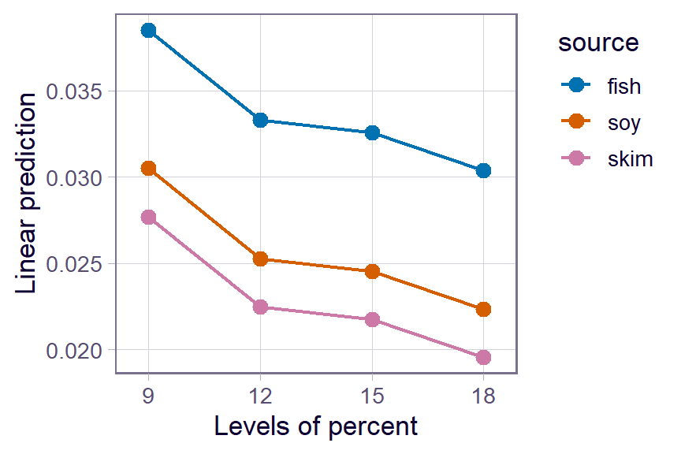

```r
emmip(RG4, source ~ percent, style = "factor")
```

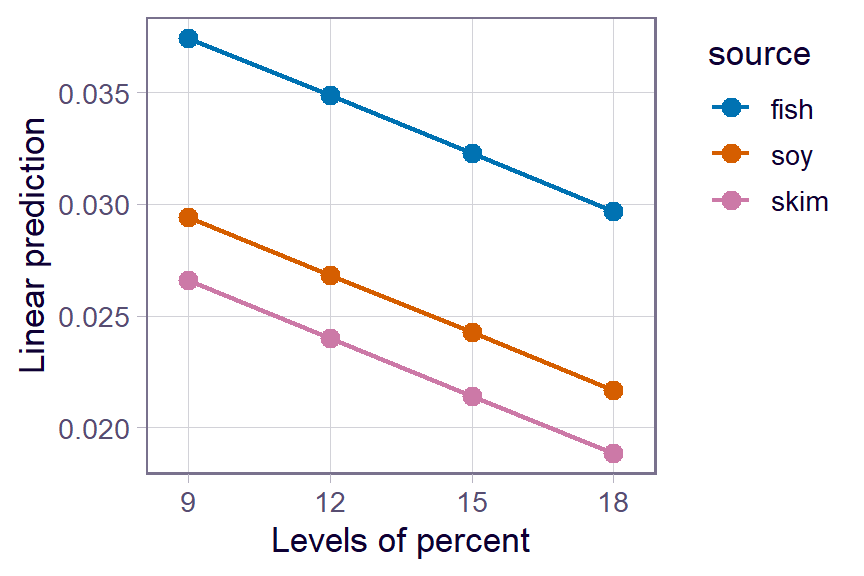

```r
emmip(RG5, source ~ percent, style = "factor")
```

Both plots show three parallel trends, because neither model includes an interaction term; but of course for `mod5`, those trends are straight lines.

Back to Contents

## Other topics

### Passing arguments

Quite a few functions in the **emmeans** package, including `emmeans()` and `emmip()`, can take either a model object or a reference-grid object as their first argument. Thus we can obtain EMMs for `mod5` directly from `RG5`, e.g.

```r
emmeans(RG5, "source")
```

```
##  source emmean       SE df lower.CL upper.CL
##  fish   0.0336 0.000958 25   0.0316   0.0355
##  soy    0.0255 0.000971 25   0.0235   0.0275
##  skim   0.0227 0.001030 25   0.0206   0.0248
##
## Results are averaged over the levels of: percent
## Results are given on the inverse (not the response) scale.
## Confidence level used: 0.95
```

These are slightly different results than we had earlier for `mod4`. In these functions where the model and the reference grid are interchangeable, the first thing the function does is to check which it is; and if it is a model object, it constructs the reference grid. When it does that, it passes its arguments to `ref_grid()` in case they are needed. For instance, the above EMMs could have been obtained using

```r
emmeans(mod5, "source", at = list(percent = c(9, 12, 15, 18)))
## (same results as above)
```

It is a great convenience to be able to pass arguments to `ref_grid()`, but it also can confuse new users, because if we look at the help page for `emmeans()`, it does not list `at` as a possible argument. It is mentioned, though, if you look at the `...` argument. So develop a habit of looking at documentation for other functions, especially `ref_grid()`, for other arguments that may affect your results.

Back to Contents

### Transformations

In our running example with `pigs`, by now you are surely tired of seeing all the answers on the `inverse(conc)` scale. What about estimating things on the `conc` scale? You may have noticed that the `inverse` transformation has not been forgotten; it is mentioned in the annotations below the `emmeans()` output. [I’d also comment that having used `inverse(conc)` rather than `1/conc` as the response variable in the model has made it easier to sort things out, because `inverse()` is a named transformation that `emmeans()` can work with.] We can back-transform the results by specifying `type = "response"` in any function call where it makes sense. For instance,

```r
emmeans(RG4, "source", type = "response")
```

```
##  source response    SE df lower.CL upper.CL
##  fish       29.7 0.816 23     28.1     31.5
##  soy        39.0 1.440 23     36.2     42.2
##  skim       43.8 1.900 23     40.1     48.1
##
## Results are averaged over the levels of: percent
## Confidence level used: 0.95
## Intervals are back-transformed from the inverse scale
```

```r
emmip(RG4, source ~ percent, type = "response")
```

[output not shown]

Transformations have a lot of nuances, and we refer you to the vignette of transformations for more details.

Back to Contents

### Derived covariates

You need to be careful when one covariate depends on the value of another. To illustrate using the `datasets::mtcars` data, suppose we want to predict `mpg` using `cyl` (number of cylinders) as a factor `disp` (displacement) as a covariate, and include a quadratic term for `disp`. Here are two equivalent models:

```r
mcmod1 <- lm(mpg ~ factor(cyl) + disp + I(disp^2), data = mtcars)
mtcars <- transform(mtcars,
                    dispsq = disp^2)
mcmod2 <- lm(mpg ~ factor(cyl) + disp + dispsq, data = mtcars)
```

These two models have exactly the same predicted values. But look at the EMMs:

```r
emmeans(mcmod1, "cyl")
```

```
##  cyl emmean   SE df lower.CL upper.CL
##    4   19.3 2.66 27     13.9     24.8
##    6   17.2 1.36 27     14.4     20.0
##    8   18.8 1.47 27     15.7     21.8
##
## Confidence level used: 0.95
```

```r
emmeans(mcmod2, "cyl")
```

```
##  cyl emmean   SE df lower.CL upper.CL
##    4   20.8 2.05 27     16.6     25.0
##    6   18.7 1.19 27     16.3     21.1
##    8   20.2 1.77 27     16.6     23.9
##
## Confidence level used: 0.95
```

Wow! Those are really different results – even though the models are equivalent. Why is this – and which (if either) is right? To understand, look at the reference grids:

```r
ref_grid(mcmod1)
```

```
## 'emmGrid' object with variables:
##     cyl = 4, 6, 8
##     disp = 230.72
```

```r
ref_grid(mcmod2)
```

```
## 'emmGrid' object with variables:
##     cyl = 4, 6, 8
##     disp = 230.72
##     dispsq = 68113
```

For both models, the reference grid uses the `disp` mean of 230.72. But for `mcmod2`, `dispsq` is a separate covariate, and it is set to its mean of 68113. This is not right, because it is impossible to have `disp` equal to 230.72 and its square equal to 68113 at the same time! If we use consistent values of `disp` and`dispsq`, we get the same results as for `mcmod1`:

```r
emmeans(mcmod2, "cyl", at = list(disp = 230.72, dispsq = 230.72^2))
```

```
##  cyl emmean   SE df lower.CL upper.CL
##    4   19.3 2.66 27     13.9     24.8
##    6   17.2 1.36 27     14.4     20.0
##    8   18.8 1.47 27     15.7     21.8
##
## Confidence level used: 0.95
```

In summary, for polynomial models and others where some covariates depend on others in nonlinear ways, it is definitely best to include that dependence in the model formula (as in `mcmod1`) using `I()` or `poly()` expressions, or alter the reference grid so that the dependency among covariates is correct.

Back to Contents

### Non-predictor variables

Reference grids are derived using the variables in the right-hand side of the model formula. But sometimes, these variables are not actually predictors. For example:

```r
deg <- 2
mod <- lm(y ~ treat * poly(x, degree = deg), data = mydata)
```

If we call `ref_grid()` or `emmeans()` with this model, it will try to construct a grid of values of `treat`, `x`, and `deg` – causing an error because `deg` is not a predictor in this model. To get things to work correctly, you need to name `deg` in a `params` argument, e.g.,

```r
emmeans(mod, ~ treat | x, at = list(x = 1:3), params = "deg")
```

Back to Contents

### Graphical displays

The results of `ref_grid()` or `emmeans()` (these are objects of class `emmGrid`) may be plotted in two different ways. One we have already seen is an interaction-style plot, using `emmip()`.

The formula specification we used in `emmip(RG4, source ~ percent)` sets the *x* variable to be the one on the right-hand side and the “trace” factor (what is used to define the different curves) on the left.

The other graphics option offered is the `plot()` method for `emmGrid` objects. Let’s consider a different model for the `mtcars` data with both `cyl` and `disp` as covariates

```r
mcmod3 <- lm(mpg ~ disp * cyl, data = mtcars)
```

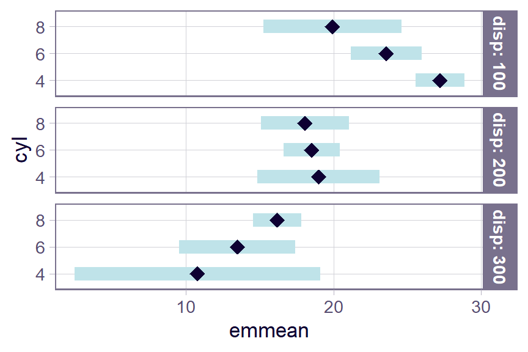

```r
EMM3 <- emmeans(mcmod3, ~ cyl | disp,
                at = list(cyl = c(4,6,8), disp = c(100,200,300)))
plot(EMM3)
```

This plot illustrates, as much as anything else, how silly it is to try to predict mileage for a 4-cylinder car having high displacement, or an 8-cylinder car having low displacement. The widths of the intervals give us a clue that we are extrapolating. A better idea is to acknowledge that displacement largely depends on the number of cylinders. So here is yet another way to use `cov.reduce` to modify the reference grid:

```r
mcrg <- ref_grid(mcmod3, at = list(cyl = c(4,6,8)),
                         cov.reduce = disp ~ cyl)
mcrg @ grid
```

```
##        disp cyl .wgt.
## 1  93.78673   4     1
## 2 218.98458   6     1
## 3 344.18243   8     1
```

The `ref_grid` call specifies that `disp` depends on `cyl`; so a linear model is fitted with the given formula and its fitted values are used as the `disp` values – only one for each `cyl`. If we plot this grid, the results are sensible, reflecting what the model predicts for typical cars with each number of cylinders:

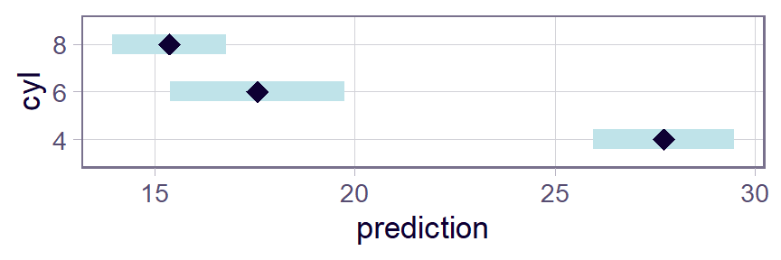

```r
plot(mcrg)
```

Wizards with the **ggplot2** package can further enhance these plots if they like. For example, we can add the data to an interaction plot – this time we opt to include confidence intervals and put the three sources in separate panels:

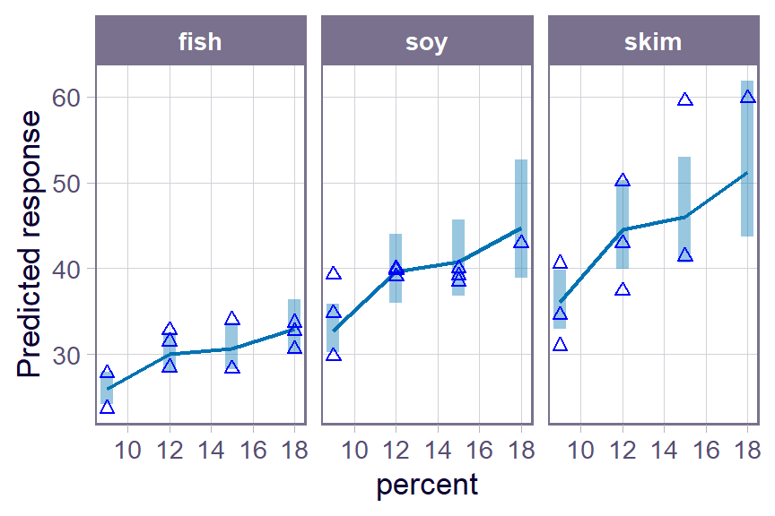

```r
require("ggplot2")
emmip(mod4, ~ percent | source, CIs = TRUE, type = "response") +
    geom_point(aes(x = percent, y = conc), data = pigs, pch = 2, color = "blue")
```

Back to Contents

### Formatting results

If you want to include `emmeans()` results in a report, you might want to have it in a nicer format than just the printed output. We provide a little bit of help for this, especially if you are using RMarkdown or SWeave to prepare the report. There is an `xtable` method for exporting these results, which we do not illustrate here but it works similarly to `xtable()` in other contexts. Also, the `export` option the `print()` method allows the user to save exactly what is seen in the printed output as text, to be saved or formatted as the user likes (see the documentation for `print.emmGrid` for details). Here is an example using one of the objects above:

```r
ci <- confint(mcrg, level = 0.90, adjust = "scheffe")
xport <- print(ci, export = TRUE)
cat("<font color = 'blue'>\n")
knitr::kable(xport$summary, align = "r")
for (a in xport$annotations) cat(paste(a, "<br>"))
cat("</font>\n")
```

|  | disp | cyl | prediction | SE | df | lower.CL | upper.CL |
| --- | --- | --- | --- | --- | --- | --- | --- |
|  | 93.8 | 4 | 27.7 | 0.858 | 28 | 25.5 | 30.0 |
|  | 219.0 | 6 | 17.6 | 1.070 | 28 | 14.8 | 20.4 |
|  | 344.2 | 8 | 15.4 | 0.692 | 28 | 13.5 | 17.2 |

Confidence level used: 0.9  
Conf-level adjustment: scheffe method with rank 3

Back to Contents

### Using weights

As we have mentioned, `emmeans()` uses equal weighting by default, based on its foundations in experimental situations. When you have observational data, you are more likely to use unequal weights that more accurately characterize the population. Accordingly, a `weights` argument is provided in `emmeans()`. For example, using `weights = "cells"` in the call will weight the predictions according to their cell frequencies (recall this information is retained in the reference grid). This produces results comparable to ordinary marginal means:

```r
emmeans(mod4, "percent", weights = "cells")
```

```
##  percent emmean       SE df lower.CL upper.CL
##        9 0.0315 0.001030 23   0.0293   0.0336
##       12 0.0270 0.000969 23   0.0250   0.0290
##       15 0.0260 0.001100 23   0.0238   0.0283
##       18 0.0266 0.001300 23   0.0239   0.0293
##
## Results are averaged over the levels of: source
## Results are given on the inverse (not the response) scale.
## Confidence level used: 0.95
```

```r
mod6 <- lm(inverse(conc) ~ factor(percent), data = pigs)
emmeans(mod6, "percent")
```

```
##  percent emmean      SE df lower.CL upper.CL
##        9 0.0315 0.00196 25   0.0274   0.0355
##       12 0.0270 0.00185 25   0.0232   0.0308
##       15 0.0260 0.00210 25   0.0217   0.0303
##       18 0.0266 0.00248 25   0.0215   0.0317
##
## Results are given on the inverse (not the response) scale.
## Confidence level used: 0.95
```

The EMMs in these two tables are identical, so in some sense, `weights = "cells"` amounts to throwing-out the uninvolved factors. However, note that these outputs show markedly different standard errors. That is because the model `mod4` accounts for variations due to `source` while `mod6` does not. The lesson here is that it is possible to obtain statistics comparable to ordinary marginal means, while still accounting for variations due to the factors that are being averaged over.

Back to Contents

### Multivariate responses

The **emmeans** package supports various multivariate models. When there is a multivariate response, the dimensions of that response are treated as if they were levels of a factor. For example, the `MOats` dataset provided in the package has predictors `Block` and `Variety`, and a four-dimensional response `yield` giving yields observed with varying amounts of nitrogen added to the soil. Here is a model and reference grid:

```r
MOats.lm <- lm (yield ~ Block + Variety, data = MOats)
ref_grid (MOats.lm, mult.name = "nitro")
```

```
## 'emmGrid' object with variables:
##     Block = VI, V, III, IV, II, I
##     Variety = Golden Rain, Marvellous, Victory
##     nitro = multivariate response levels: 0, 0.2, 0.4, 0.6
```

So, `nitro` is regarded as a factor having 4 levels corresponding to the 4 dimensions of `yield`. We can subsequently obtain EMMs for any of the factors `Block`, `Variety`, `nitro`, or combinations thereof. The argument `mult.name = "nitro"` is optional; if it had been excluded, the multivariate levels would have been named `rep.meas`.

Back to Contents

## Objects, structures, and methods

The `ref_grid()` and `emmeans()` functions are introduced previously. These functions, and a few related ones, return an object of class `emmGrid`. From previously defined objects:

```r
class(RG4)
```

```
## [1] "emmGrid"
## attr(,"package")
## [1] "emmeans"
```

```r
class(EMM.source)
```

```
## [1] "emmGrid"
## attr(,"package")
## [1] "emmeans"
```

If you simply show these objects, you get different-looking results:

```r
RG4
```

```
## 'emmGrid' object with variables:
##     source = fish, soy, skim
##     percent =  9, 12, 15, 18
## Transformation: "inverse"
```

```r
EMM.source
```

```
##  source emmean       SE df lower.CL upper.CL
##  fish   0.0337 0.000926 23   0.0318   0.0356
##  soy    0.0257 0.000945 23   0.0237   0.0276
##  skim   0.0229 0.000994 23   0.0208   0.0249
##
## Results are averaged over the levels of: percent
## Results are given on the inverse (not the response) scale.
## Confidence level used: 0.95
```

This is based on guessing what users most need to see when displaying the object. You can override these defaults; for example to just see a quick summary of what is there, do

```r
str(EMM.source)
```

```
## 'emmGrid' object with variables:
##     source = fish, soy, skim
## Transformation: "inverse"
```

The most important method for `emmGrid` objects is `summary()`. It is used as the print method for displaying an `emmeans()` result. For this reason, arguments for `summary()` may also be specified within most functions that produce `these kinds of results.`emmGrid` objects. For example:

```r
# equivalent to summary(emmeans(mod4, "percent"), level = 0.90, infer = TRUE))
emmeans(mod4, "percent", level = 0.90, infer = TRUE)
```

```
##  percent emmean       SE df lower.CL upper.CL t.ratio p.value
##        9 0.0322 0.001030 23   0.0305   0.0340  31.240  <.0001
##       12 0.0270 0.000969 23   0.0253   0.0287  27.872  <.0001
##       15 0.0263 0.001100 23   0.0244   0.0282  23.802  <.0001
##       18 0.0241 0.001340 23   0.0218   0.0264  18.009  <.0001
##
## Results are averaged over the levels of: source
## Results are given on the inverse (not the response) scale.
## Confidence level used: 0.9
```

This `summary()` method for `emmGrid` objects) actually produces a `data.frame`, but with extra bells and whistles:

```r
class(summary(EMM.source))
```

```
## [1] "summary_emm" "data.frame"
```

This can be useful to know because if you want to actually *use* `emmeans()` results in other computations, you should save its summary, and then you can access those results just like you would access data in a data frame. The `emmGrid` object itself is not so accessible. There is a `print.summary_emm()` function that is what actually produces the output you see above – a data frame with extra annotations.

Back to Contents

## P values, “significance”, and recommendations

There is some debate among statisticians and researchers about the appropriateness of *P* values, and that the term “statistical significance” can be misleading. If you have a small *P* value, it *only* means that the effect being tested is unlikely to be explained by chance variation alone, in the context of the current study and the current statistical model underlying the test. If you have a large *P* value, it *only* means that the observed effect could plausibly be due to chance alone: it is *wrong* to conclude that there is no effect.

For some time I included a summary of Wasserstein *et al.*’s recommendations and their *ATOM* paradigm (Acceptance of uncertainty, Thoughtfulness, Openness, Modesty). But in the meantime, I have handled a large number of user questions, and many of those have made it clear to me that there are more important fish to fry in a vignette section like this. It is just a fact that *P* values are used, and are useful. So I have my own set of recommendations regarding them.

#### A set of comparisons or well-chosen contrasts is more useful and interpretable than an omnibus *F* test

*F* tests are useful for model selection, but don’t tell you anything specific about the nature of an effect. If *F* has a small *P* value, it suggests that there is some effect, somewhere. It doesn’t even necessarily imply that any two means differ statistically.

#### Use *adjusted* *P* values

When you run a bunch of tests, there is a risk of making too many type-I errors, and adjusted *P* values (e.g., the Tukey adjustment for pairwise comparisons) keep you from making too many mistakes. That said, it is possible to go overboard; and it’s usually reasonable to regard each “by” group as a separate family of tests for purposes of adjustment.

#### It is *not* necessary to have a significant *F* test as a prerequisite to doing comparisons or contrasts

… as long as an appropriate adjustment is used. There do exist rules such as the “protected LSD” by which one is given license to do unadjusted comparisons provided the $F$ statistic is “significant.” However, this is a very weak form of protection for which the justification is, basically, “if $F$ is significant, you can say absolutely anything you want.”

#### Get the model right first

Everything the **emmeans** package does is an interpretation of the model that you fitted to the data. If the model is bad, you will get bad results from `emmeans()` and other functions. Every single limitation of your model, be it presuming constant error variance, omitting interaction terms, etc., becomes a limitation of the results `emmeans()` produces. So do a responsible job of fitting the model. And if you don’t know what’s meant by that…

#### Consider seeking the advice of a statistical consultant

Statistics is *hard*. It is a lot more than just running programs and copying output. We began this vignette by emphasizing we need to start with a good model; that is an artful task, and certainly what is shown here only hints at what is required; you may need help with it. It is *your* research; is it important that it be done right? Many academic statistics and biostatistics departments can refer you to someone who can help.

Back to Contents

## Summary of main points

- EMMs are derived from a *model*. A different model for the same data may lead to different EMMs.
- EMMs are based on a *reference grid* consisting of all combinations of factor levels, with each covariate set to its average (by default).
- For purposes of defining the reference grid, dimensions of a multivariate response are treated as levels of a factor.
- EMMs are then predictions on this reference grid, or marginal averages thereof (equally weighted by default).
- Reference grids may be modified using `at` or other arguments for `ref_grid()`
- Reference grids and `emmeans()` results may be plotted via `plot()` (for parallel confidence intervals) or `emmip()` (for an interaction-style plot).
- Be cautious with the terms “significant” and “nonsignificant”, and don’t ever interpret a “nonsignificant” result as saying that there is no effect.
- Follow good statistical practices such as getting the model right first, and using adjusted *P* values for appropriately chosen families of comparisons or contrasts.

Back to Contents

### References

Wasserstein RL, Lazar NA (2016) “The ASA’s Statement on *p*-Values: Context, Process, and Purpose,” *The American Statistician*, **70**, 129–133, https://doi.org/10.1080/00031305.2016.1154108

Wasserstein RL, Schirm AL, Lazar, NA (2019) “Moving to a World Beyond ‘p < 0.05’,” *The American Statistician*, **73**, 1–19, https://doi.org/10.1080/00031305.2019.1583913

## Further reading

The reader is referred to other vignettes for more details and advanced use. The strings linked below are the names of the vignettes; i.e., they can also be accessed via `vignette("`*name*`", "emmeans")`

- Models that are supported in **emmeans** (there are lots of them) “models”
- Confidence intervals and tests: “confidence-intervals”
- Often, users want to compare or contrast EMMs: “comparisons”
- Working with response transformations and link functions: “transformations”
- Multi-factor models with interactions: “interactions”
- Working with messy data and nested effects: “messy-data”
- Making predictions from your model: “predictions”
- Examples of more sophisticated models (e.g., mixed, ordinal, MCMC) “sophisticated”
- Utilities for working with `emmGrid` objects: “utilities”
- Frequently asked questions: “FAQs”
- Adding **emmeans** support to your package: “xtending”

Back to Contents

Index of all vignette topics